[figure not shown]

# Методы машинного обучения

### Шестаков Андрей (avshestakov@hse.ru)

## Метрические методы

# Гипотеза компактности

Метрические методы классификации и регрессии - одни из самых простых моделей.

Они основаны на **гипотезе компактности** - близким объектам соответствуют близкие ответы. Можно встретить довольно много прецедентов, связанных с этой гипотезой

## Сегрегация населения в городах

[figure not shown]

## Стоимость жилья в зависимости от расположения

[figure not shown]

## "Похожесть" генов и их функции

[figure not shown]

## Категоризация статей по содержимому

[figure not shown]

# Меры близости

- Как определить похожие объекты?
- Необходимо ввести функцию расстояния межну ними

### Самые популярные

$$ d(a, b) = \sqrt{\sum\limits_{i=1}^{D}(a_i - b_i)^2} \text{: euclidean distance} $$$$ d(a, b) = \sum\limits_{i=1}^{D}|a_i - b_i| \text{: manhattan distance} $$$$ d(a, b) = 1 - \frac{\langle a,b \rangle}{||a||_2\cdot||b||_2} \text{: cosine distance} $$

## Illustration

[figure not shown]

## Расстояние на строках

- Расстояние Левенштейна  
  Количество вставок, замен и удалений, которое необходимо сделать, чтобы получить из строки $S_1$ строку $S_2$

\begin{equation} D ( i , j ) = \begin{cases} {\begin{array}{llcl}0,&&&i=0,\ j=0\\i,&&&j=0,\ i>0\\j,&&&i=0,\ j>0\\\min\{\\&D(i,j-1)+1,\\&D(i-1,j)+1,&&j>0,\ i>0\\&D(i-1,j-1)+{\rm {m}}(S_{1}[i],S_{2}[j])\\\}\end{array}}, \end{cases} \end{equation}

где $m(a,b)$ - равно $0$, если $a = b$ и $1$ в ином случае

[figure not shown]

## Близость на бинарных векторах

- Пусть объект описываеться набором бинарных признаков  
  (достиг 18 лет, отслужил в армии, закончил университет, женат)
  - Иван: `(1, 0, 1, 0)`
  - Геннадий: `(1, 1, 0, 1)`
- Расстояние Хэмминга - Hamming distance
  - Количество (доля) несовпавших значений

    $$d(\text{Иван},\text{Геннадий}) = 3 $$

## Близость на множествах

- Пусть объект описываеться набором категорий, слов, тегов
  - Клиент a: {Картофель фри, биг-мак, кофе, маффин}
  - Клиент b: {Картофель фри, сырный соус, чизбургер, кофе, пирожок}
- Расстояние Жаккара - Jaccard distance:
  - $$d(a,b) = 1 - \frac{|a \cap b|}{|a \cup b|}$$
  - $$d(a,b) = 1 - \frac{2}{7} = \frac{5}{7} $$
- При правильном представлении данных, можно считать и косинус

# Метод ближайших центройдов

## Алгоритм МБЦ

- Вход: обучающая выборка $X=\{\left(x_{1},y_{1}\right),...\left(x_{N},y_{N}\right)\}$ и тестовый объект $\tilde{x}$
- Пусть
  - $N_{1}$ - количество представителей класса 1
  - $N_{2}$ - количество представителей класса 2
  - итд.
- **Обучение:**
  - Вычислим расположение центройдов для классов $c=1,2,...C:$ $$ \mu_{c}=\frac{1}{N_{с}}\sum_{i \in S_c}x_{i} $$
  - Все
- **Классификация:**
  - Для тестового объекта $\tilde{x}$ надо найти самый ближайший центройд: $$ c=\arg\min_{i}d(x,\mu_{i}) $$
  - Отнести $x$ к классу ближайшего центройда: $$ \widehat{y}(x)=c $$
- Примечание - формулы справедливы то евлидового расстояния

## Пример для 4х классов

```python
interact(plot_centroid_class)
```

```
<function __main__.plot_centroid_class()>
```

## Обсуждение

- Как можнь было бы посчитать "вероятность" принадлежности к класса?
- Как можно адаптировать этот подход для регрессии?

# Метод k ближайших соседей (KNN)

## Метод k ближайших соседей (для классификации)

Вход: Обучающая выборка $X=(x_i,y_i)$, мера близости $d(\cdot, \cdot)$ и тестовый объект $\tilde{x}$

Найти $k$ ближайших объекта в $X$ c помощью $d(\tilde{x},\cdot)$

- (классификация) вернуть наиболее частую метку класса
- (вероятность) вернуть долю объектов каждого из классов среди ближайших соседей

[figure not shown]

```
Text(0,0.5,'$x_2$')
```

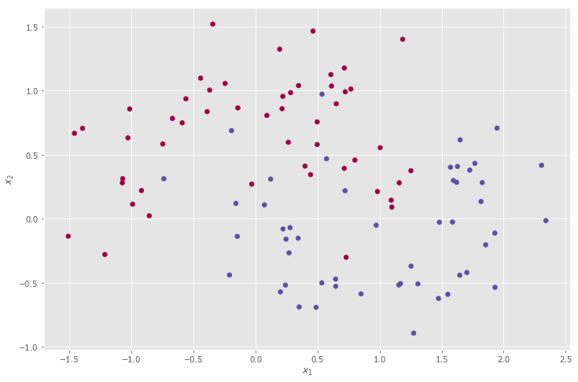

```python
plt.scatter(X_moons[:,0], X_moons[:,1], c=y_moons, cmap=plt.cm.Spectral)
plt.xlabel('$x_1$')
plt.ylabel('$x_2$')
```

```python
interact(plot_knn_class, k=IntSlider(min=1, max=10, value=1))
```

```
<function __main__.plot_knn_class(k=1, prob=False)>
```

## Метод k ближайших соседей (для регрессии)

- Найти $k$ ближайших объектов из обучающей выборки для $\tilde{x}$
- Усреднить ответы блишайших соседей и присвоить результат $\tilde{x}$

[figure not shown]

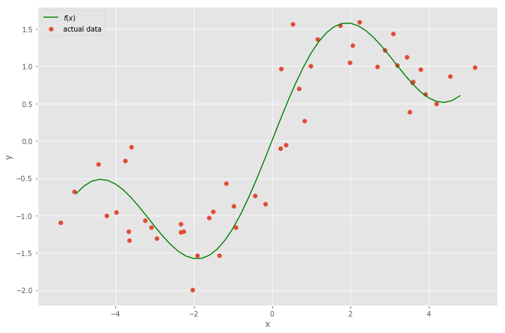

```python
plt.plot(x_true, y_true, c='g', label='$f(x)$')
plt.scatter(x, y, label='actual data')
plt.xlabel('x')
plt.ylabel('y')
plt.legend(loc=2)
```

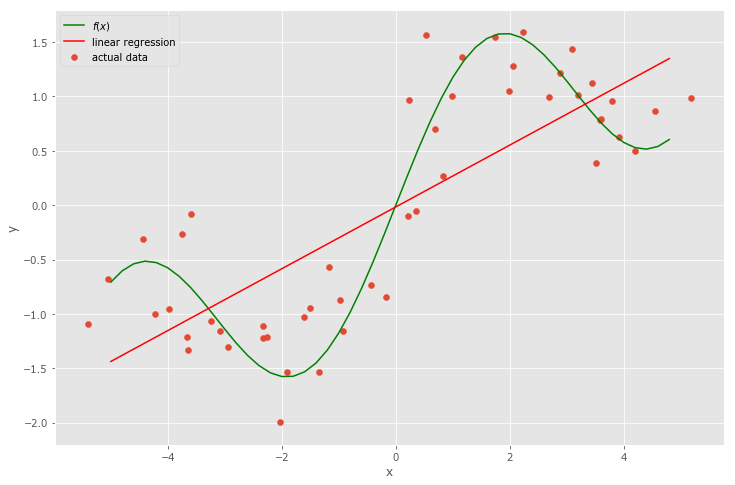

```python
plot_linreg()
```

```python
interact(plot_knn, k=IntSlider(min=1, max=10, value=1))
```

```
<function __main__.plot_knn(k=1)>
```

# Параметры vs Гиперпараметры алгоритмов

## Параметры vs Гиперпараметры

При работе с моделями следует различать понятия **Параметр** и **Гипер-параметр**.

- **Параметр** - составляющая модели, которая определяется в процессе обучения самой моделью
  - Веса коэффициентов в модели линейной регрессии
- **Гиперпараметр** - составляющая модели, которая задается перед началом обучения. Может регулировать некоторые свойства модели или ее сложность
  - Коэффициент регуляризации в линейной регрессии

Как дела обстоят у kNN?

- kNN - непараметрическая модель!
- kNN - ленивая модель (lazy learning)!

## Нормализация признаков

- Шкалы признаков влияют на рассчет расстояния
- Разные масштабы шкал - разный вклад признаков
- Стандартные способы нормализации:
  - z-scoring: $$x_{j}'=\frac{x_{j}-\mu_{j}}{\sigma_{j}}$$
  - интервальное шкалирование: $$x_{j}'=\frac{x_{j}-L_{j}}{U_{j}-L_{j}}$$

где $x_j$ - $j$-ый признак  
$\mu_{j}$ - среднее значение признака $x_j$,  
$\sigma_{j}$ - его стандартное отклонение  
$L_{j}$ и $U_{j}$ - верхняя и нижняя "границы"

# Взвешенный kNN

## Взвешенный kNN

[figure not shown]

## Взвешенный kNN

У каждого ближайшего соседа возникает "вес" важности в предсказании. Пусть $(j)$ показывает порядок ближайшего соседа, тогда:

- (регрессия) вернуть среднее взвешенное значение* $$\hat{y} = \frac{\sum\limits_{j=1}^k w_{(j)} y_{(j)}}{\sum\limits_{j=1}^k w_{(j)}}$$
- (классификация) вернуть наиболее частую метку класса c учетом веса $$\hat{y} = \arg \max\limits_{с}\sum\limits_{j=1}^k w_{(j)} [y_{(j)} == с] $$

### Варианты весов

- $w_{(j)}=\alpha^{k},\quad\alpha\in(0,1)$
- $w_{(j)} = \frac{k - j + 1}{k}$
- $w_{(j)} = 1/d(\tilde{x},x_{(j)})$

```python
interact(plot_knn_dist, k=IntSlider(min=1, max=10, value=1))
```

```
<function __main__.plot_knn_dist(k=1)>
```

```python
interact(plot_knn_class_kernel, k=IntSlider(min=1, max=10, value=1))
```

```
<function __main__.plot_knn_class_kernel(k=1, prob=False)>
```

# Меры качества классификации

## Меры качества классификации

- Как правило, классификаторы выдают не просто предсказанную метку класса, но и степень уверенности в ней
- Основные меры качества
  - Accuracy
  - Precision, Recall, F-measure
  - ROC-AUC, PR-AUC Gini-index, Model-lift
  - Log-loss

## Матрица перемешивания

Матрица перемешивания $M=\{m_{ij}\}_{i,j=1}^{C}$ показывает количество объектов класса $с_{i}$, которые были отнесены классификатором к классу $с_{j}$.

[figure not shown]

## Матрица перемешивания (2 класса)

[figure not shown]

- TP (true positive) - Верное предсказание (+1)
- FP (false positive) - Ошибка первого рода (ложная тревога)
- FN (false negative) - Ошибка второго рода (пропуск цели)
- TN (true negative) - Верное предсказание (-1)
- Pos (Neg) - Общее количество +1 и -1

## Меры на основе матрицы перемешивания

[figure not shown]

- $ \text{accuracy} = \frac{TP + TN}{Pos+Neg}$
- $ \text{error rate} = 1 -\text{accuracy}$
- $ \text{recall} =\frac{TP}{TP + FN} = \frac{TP}{Pos}$ - (полнота)
- $ \text{precision} =\frac{TP}{TP + FP}$ - (точность)
- $ \text{F}_\beta \text{-score} = \frac{1+\beta^2}{\frac{1}{Recall} + \frac{1}{\beta^2 Precision}} = (1 + \beta^2) \cdot \frac{\mathrm{precision} \cdot \mathrm{recall}}{(\beta^2 \cdot \mathrm{precision}) + \mathrm{recall}}$
  - почему не среднее или максимум?
- Можно ли посчитать эти меры для многоклассовой классификации?

```python
fig = interact(demo_fscore, beta=FloatSlider(min=0.1, max=5, step=0.3, value=1))
```

## Меры качества на основе уверенности классификатора

## ROC кривая

- Выбор порога классификации - отдельная большая задача
- Можно ли как-то обойтись без него и сравнить неколько моделей?
- ROC кривая - показывает зависимость между TPR (верным предсказанием) и FPR (ложным срабатыванием)

[figure not shown]

## ROC кривая

- Классификатор $a(x)$ возвращает степень принадлежности к классу "+1" - score(x).
- Упорядочим объекты по убыванию score(x)
- Смотрим сверху вниз
  - Если объект принадлежит классу "+1" - сдвиг вверх на $1/Pos$
  - Если объект принадлежит классу "-1" - сдвиг вправо на $1/Neg$

## Как сравнивать ROC-кривые?

[figure not shown]

## ROC-AUC

- Площадь под ROC кривой
- AUC$\in[0,1]$
  - AUC = 0.5 - случайный классификатора
  - AUC = 1 - идеальный классификатор

## Precision-Recall Кривая

- Строится аналогичным образом, но по осям Precision и Recall для разных порогов

[figure not shown]